# Grado en Ciencia de Datos.

### Árboles para clasificación

Para entender cómo funcionan los árboles de clasificación vamos a construirnos un árbol con un solo nodo. Usaremos el dataset IRIS que tiene tres clases distintas. Las entradas `X` son de 4 variables. La idea es encontrar la variable que más ayuda a clasificar cuando fijamos un umbral de manera que clasificamos las muestras en dos grupos según superen dicho umbral. Para decidir si los grupos generados están mejor clasificados tendremos que usar alguna métrica. En árboles de decisión se usan normalmente la entropía (E) o el índice Gini (G).

La entropía viene definida por $$ E=-\sum_c P_c\log_2 P_c $$

El índice Gini se define por $$ G = \sum_c P_c(1-Pc) = 1-\sum_c P_c^2 $$

Siendo $P_c$ es la probabilidad (estimada) de cada clase. Para ambas medidas si valen 0 significan que tenemos solo una clase en el grupo, caso contrario cuanto más alto su valor más clases tenemos en un grupo.

```python
import numpy as np
import matplotlib.pyplot as plt
%matplotlib inline
from sklearn.datasets import load_iris

# Empezaremos usando la entropía. Luego probaremos Gini.
def entropy(y):
    prob = [np.sum(y==c) for c in set(y)]
    prob /= np.sum(prob)
    entropy = np.sum(-prob * np.log2(prob)) if all(prob != 0) else 0
    return entropy

X, y = load_iris(return_X_y=True)
#X.shape[1]
#X[:,0]
```

Comenzamos calculando la entropía actual del conjunto de datos. Después buscaremos particiones de manera sistemática a ver si damos con una que al aplicarla disminuya el valor de la entropía. Recordemos que el objetivos sería encontrar grupos con entropía igual a cero, es decir, formados por una sola clase.

```python
# Entropía inicial de todo el conjunto
entropy_root = entropy(y)

# Empezamos la búsqueda
entropy_min = entropy_root
feature = 0
threshold = None
# Probamos con todas las variables de X ...
for feat in range(X.shape[1]):
    # Y para cada variable con todos sus posibles valores ...
    for th in X[:,feat]:
        # Índice para seleccionar las muestras por debajo del umbral th
        idx = X[:,feat] <= th
        # Dividimos en dos grupos, izquierda y derecha
        left = y[idx]
        right = y[~idx]
        # Medimos sus entropías
        entropy_left = entropy(left)
        entropy_right = entropy(right)
        # Y si la suma ponderada es menor que la actual, actualizamos
        if (entropy_left*len(left) + entropy_right*len(right))/len(y) < entropy_min:
            entropy_min = (entropy_left*len(left) + entropy_right*len(right))/len(y)
            feature = feat
            threshold = th



# Veamos si hemos tenido éxito en nuestra búsqueda
if threshold is None:
    print('Dividir no mejora')
else:
    print('Mejora con feature %d y threshold %f' %
            (feature, threshold))
    idx = X[:,feature] <= threshold
    left = y[idx]
    right = y[~idx]
    entropy_left = entropy(left)
    entropy_right = entropy(right)
    weighted_entropy = (entropy_left*len(left) + entropy_right*len(right))/len(y)
    print('  entropía left  %5.3f' % entropy_left)
    print('  entropía right %5.3f' % entropy_right)
    print('  entropía total %5.3f' % weighted_entropy)
    print('  entropía root %5.3f ' % entropy_root)

    print('Muestras en left\n', left)
    print('Muestras en right\n', right)
```

```
Mejora con feature 2 y threshold 1.900000
  entropía left  0.000
  entropía right 1.000
  entropía total 0.667
  entropía root 1.585
Muestras en left
 [0 0 0 0 0 0 0 0 0 0 0 0 0 0 0 0 0 0 0 0 0 0 0 0 0 0 0 0 0 0 0 0 0 0 0 0 0
 0 0 0 0 0 0 0 0 0 0 0 0 0]
Muestras en right
 [1 1 1 1 1 1 1 1 1 1 1 1 1 1 1 1 1 1 1 1 1 1 1 1 1 1 1 1 1 1 1 1 1 1 1 1 1
 1 1 1 1 1 1 1 1 1 1 1 1 1 2 2 2 2 2 2 2 2 2 2 2 2 2 2 2 2 2 2 2 2 2 2 2 2
 2 2 2 2 2 2 2 2 2 2 2 2 2 2 2 2 2 2 2 2 2 2 2 2 2 2]
```

No está nada mal. Con solo una división hemos conseguido meter a todas las muestras de la clase 0 en el grupo de la izquierda! Ahora solo faltaría repetir el procedimiento para subdividir al grupo de la derecha. Seguro que has entendido el concepto!

Nuestro árbol de juguete está muy bien para aprender, pero a la hora de clasificar "en serio" tendremos que buscar implementaciones más optimizadas. En scikit-learn tenemos `DecisionTreeClassifier`. Repitamos rápidamente el ejercicio anterior usando este clasificador.

https://scikit-learn.org/stable/modules/generated/sklearn.tree.DecisionTreeClassifier.html#sklearn.tree.DecisionTreeClassifier

Veamos un ejemplo de cómo utilizar las funciones de creación de árboles de scikitlearn.

```python
from sklearn.model_selection import train_test_split
from sklearn.tree import DecisionTreeClassifier

Xtrain, Xtest, ytrain, ytest = train_test_split(X, y, test_size=0.3)

#Construimos el objeto que contendrá el árbol

# Nota: por defecto usa la entropia de gini
#criterion{“gini”, “entropy”}, default=”gini”
dtc = DecisionTreeClassifier(criterion='entropy')
#dtc = DecisionTreeClassifier(criterion='gini')

#Lo entrenamos
dtc.fit(Xtrain, ytrain)

#Lo evaluamos en test...
dtc.score(Xtest, ytest)
#dtc.score(Xtrain, ytrain)
```

```
0.9555555555555556
```

Scikit-learn nos da la posibilidad de representar el árbol gráficamente. Esto es muy relevante puesto que una de las características más importantes de los árboles de decisión es su facilidad para interpretarlos. Una vez entrenado el árbol, este pone de manifiesto cuáles son las variables más importantes en el proceso de clasificación, y cuáles son los valores críticos (umbrales) de las mismas.

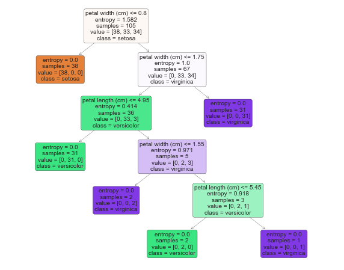

```python
from sklearn.tree import plot_tree

iris = load_iris()

plt.figure(figsize=(10,8))

#plot_tree permite visualizar el árbol
plot_tree(dtc, feature_names=iris.feature_names,
          class_names=iris.target_names, filled=True,
          rounded=True, fontsize=10);
```

También es interesante visualizar como el árbol particiona el espacio de entrada para realizar la clasificación. Veamos un ejemplo de clasificación empleando únicamente dos variables de entrada para visualizar el concepto que estamos presentando.

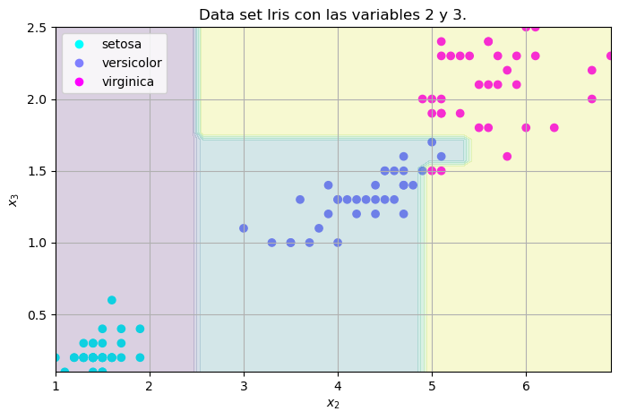

```python
#Definimos la red para conseguir las fronteras de clasificación

varx, vary = 2, 3
minx, maxx = np.min(X[:,varx]), np.max(X[:,varx])
miny, maxy = np.min(X[:,vary]), np.max(X[:,vary])

npoints = 50
xx = np.linspace(minx, maxx, npoints)
yy = np.linspace(miny, maxy, npoints)

# Rentrenamos el árbol usando solo varx y vary
dtc.fit(Xtrain[:,[varx, vary]], ytrain)

#Hacemos inferencia en toda la red que hemos definido para pintar el contorno
xx, yy = np.meshgrid(xx, yy)
zz = np.zeros((npoints, npoints))
for i in range(npoints):
    for j in range(npoints):
        zz[i,j] = dtc.predict(np.c_[xx[i,j], yy[i,j]])


#Pintamos las fronteras del árbol y las clases del dataset
plt.style.use('default')
fig,ax = plt.subplots(figsize=(8,5))
sc=ax.scatter(Xtrain[:, varx], Xtrain[:, vary],
                 c=ytrain, cmap=plt.get_cmap('cool'))

ax.set_xlabel('$x_2$')
ax.set_ylabel('$x_3$')
ax.set_title('Data set Iris con las variables 2 y 3.')

#Pintamos las fronteras de clasificación del árbol
ax.contourf(xx, yy, zz, alpha=0.2)
h, l = sc.legend_elements()
ax.legend(h,iris.target_names), plt.grid(1);
```

Otra característica muy interesante de los árboles implementados en scikit-learn es que una vez entrenados retornan un ranking que muestra las variables más importantes (las más usadas para realizar las particiones y las que figuran en los primeros nodos del árbol). Puedes emplear el atributo `feature_importances_` para conocer la importancia de cada variable, de este modo el árbol se convierte también en un método de selección de características.

```python
dtc.feature_importances_
```

```
array([0.67381085, 0.32618915])
```

**Ejercicio.** Utiliza `DecisionTreeClassifier` con el dataset `load_breast_cancer`.

- Carga el data set breast_cancer
- Entrena un modelo con el 60% de los datos. Evalúa el acierto promedio en test.
- Muestra el árbol gráficamente.
- Crea un ranking ordenando las variables por rango de importancia.
- Reproduce los apartados anteriores, pero cambiando la estrategia. Reduce la dimensionalidad del problema usando una PCA con 4 características, normaliza si lo consideras oportuno y cuidado con la división train/test para normalizar y hacer PCA.
- Compara los resultados (a nivel de accuracy) entre ambas aproximaciones utilizando la misma división de train y test. Repite el experimento de comparación varias veces. ¿Observas alguna diferencia?

```python
from sklearn.datasets import load_breast_cancer
cancer = load_breast_cancer()
X,y = load_breast_cancer(return_X_y=True)
```

```python
Xtrain, Xtest, ytrain, ytest = train_test_split(X, y, test_size=0.4)

dtc = DecisionTreeClassifier(criterion='entropy')
dtc.fit(Xtrain, ytrain)
dtc.score(Xtest, ytest)
```

```
0.9298245614035088
```

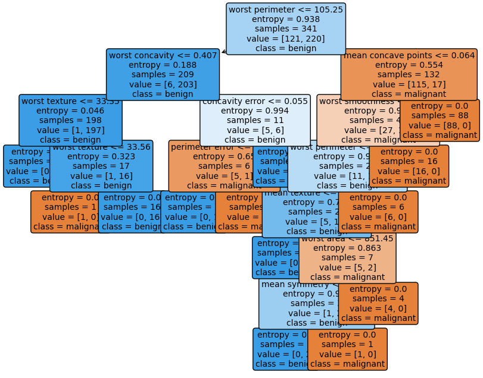

```python
plt.figure(figsize=(10,8))

plot_tree(dtc, feature_names=cancer.feature_names,
          class_names=cancer.target_names, filled=True,
          rounded=True, fontsize=10);
```

```python
a = dtc.feature_importances_
orden = sorted(range(len(a)), key=lambda k: a[k])
for index in reversed(orden):
    print(cancer.feature_names[index], '=', a[index])
```

```
worst perimeter = 0.6801138063362725
mean concave points = 0.09624673865060167
worst concavity = 0.06020135179923583
worst smoothness = 0.047757764422019434
mean texture = 0.03428226371485894
worst texture = 0.028341809813028387
concavity error = 0.021984235876851978
perimeter error = 0.012189233220165125
worst area = 0.01027284540710481
mean symmetry = 0.008609950759861274
worst fractal dimension = 0.0
worst symmetry = 0.0
worst concave points = 0.0
worst compactness = 0.0
worst radius = 0.0
fractal dimension error = 0.0
symmetry error = 0.0
concave points error = 0.0
compactness error = 0.0
smoothness error = 0.0
area error = 0.0
texture error = 0.0
radius error = 0.0
mean fractal dimension = 0.0
mean concavity = 0.0
mean compactness = 0.0
mean smoothness = 0.0
mean area = 0.0
mean perimeter = 0.0
mean radius = 0.0
```

```
0.9181286549707602
[0.71095191 0.17501677 0.06616485 0.04786647]
```

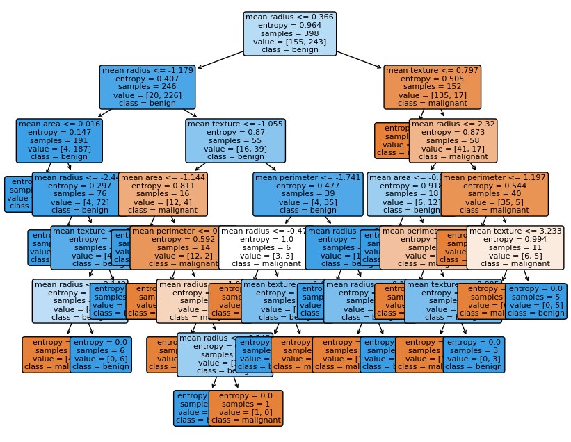

```python
pca = PCA(n_components=4)

Xstd = preprocessing.scale(X)
Xtrain, Xtest, ytrain, ytest = train_test_split(Xstd, y, test_size=0.3)

Xtrain_pca = pca.fit_transform(Xtrain)
Xtest_pca = pca.fit_transform(Xtest)
Xt = pca.fit_transform(Xstd)

dtc = DecisionTreeClassifier(criterion='entropy')
dtc.fit(Xtrain_pca, ytrain)
score = dtc.score(Xtest_pca, ytest)
print(score)

plt.figure(figsize=(10,8))
plot_tree(dtc, feature_names=cancer.feature_names,
          class_names=cancer.target_names, filled=True,
          rounded=True, fontsize=8);

a = dtc.feature_importances_
print(a)
```

La precisión más baja después de aplicar PCA podría deberse a la pérdida de información al reducir la dimensionalidad.

### Árboles para regresión

La base del funcionamiento de los árboles para regresión es la misma que para clasificación: buscamos las variables más descriptivas para particionar el espacio de entrada para modelizar la función de salida.

Las diferencias con los árboles para clasificación son:

- En cada nodo (grupo) en lugar de predecir según la clase más numerosa se predice tomando la media de las muestras que lo componen.
- La medida para subdividir cada nodo es el MSE, MAE o similares.

Para ilustrar su funcionamiento usaremos el MSE: $$ \textrm{MSE} = \frac{1}{N}\sum(y_i-\overline{y})^2 $$

donde $\overline{y}$ es la media de las muestras en un nodo. Esto es lo mismo que decir que se va a utilizar la varianza de las muestras en cada nodo. Para ilustrar el problema de regresión utilizaremos un problema juguete de puntos distribuidos en una señal *sinc*.

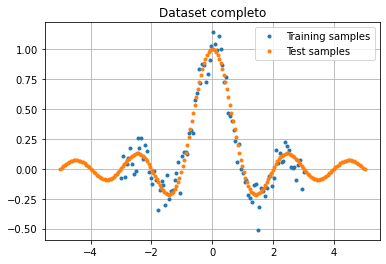

```python
#Generamos datos del problema juguete

import numpy as np
import matplotlib.pyplot as plt
%matplotlib inline

xtrain = np.linspace(-3, 3, 100)
ytrain = np.sinc(xtrain) + \
     0.1 * np.random.randn(xtrain.shape[0])
#0.05 * np.random.randn(xtrain.shape[0])
xtest = np.linspace(-5, 5, 200)
ytest = np.sinc(xtest)


plt.plot(xtrain, ytrain, '.', label='Training samples')
plt.plot(xtest, ytest, '.', label='Test samples')
plt.legend(), plt.grid(1);
plt.title('Dataset completo')



# Nuestro algoritmo necesita que las X sean 2D, hacemos un reshape!!!
xtrain, xtest = xtrain.reshape(-1,1), xtest.reshape(-1,1) # Forzamos a 2 vectores columna
```

En scikit-learn tenemos la función `DecisionTreeRegressor`.

https://scikit-learn.org/stable/modules/generated/sklearn.tree.DecisionTreeRegressor.html#sklearn.tree.DecisionTreeRegressor

```python
from sklearn.tree import DecisionTreeRegressor

dtr = DecisionTreeRegressor()
dtr.fit(xtrain, ytrain)

print('Score train %f'% (dtr.score(xtrain, ytrain)))
print('Score test %f'% (dtr.score(xtest, ytest)))
```

```
Score train 1.000000
Score test 0.910867
```

**Ejercicio** ¿Por qué crees que el *score* en entrenamiento es 1 ? Realiza un barrido de la profundidad del árbol desde 1 hasta 10 y justifica qué profundidad elegirías.

Un valor de 1 en el score de entrenamiento podría significar un sobreajuste de este grupo de datos. El modelo ha aprendido perfectamente los datos de entrenamiento, pero puede tener dificultades para generalizar a datos nuevos.

```python
for i in range(1, 11):
    dtr = DecisionTreeRegressor(max_depth=i)
    dtr.fit(xtrain, ytrain)

    train_score = dtr.score(xtrain, ytrain)
    test_score = dtr.score(xtest, ytest)

    print('Profundidad: ', (i, train_score, test_score))
```

```
Profundidad:  (1, 0.18838035237172046, 0.04436764409710647)
Profundidad:  (2, 0.7414877773779833, 0.7756629187143849)
Profundidad:  (3, 0.8842404820101911, 0.8823196734437388)
Profundidad:  (4, 0.9438972767187487, 0.8968238270438108)
Profundidad:  (5, 0.9670441729459487, 0.9393386288618406)
Profundidad:  (6, 0.9845874648202767, 0.9231305783026974)
Profundidad:  (7, 0.9914839510182486, 0.9186297364883641)
Profundidad:  (8, 0.9946343690177611, 0.9154849379880063)
Profundidad:  (9, 0.9977970201596092, 0.9119619276029636)
Profundidad:  (10, 0.999726339247151, 0.9110514736237761)
```

Generamos un nuevo árbol con una profundidad dada, por ejemplo 4

```
0.9438972767187487
```

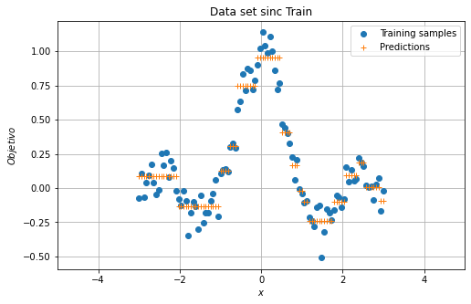

```python
# Gráficamente ...

# Generamos un nuevo árbol con una profundidad dada, por ejemplo 4
dtr = DecisionTreeRegressor(max_depth=4)
dtr.fit(xtrain, ytrain)
#Train
yp = dtr.predict(xtrain)

fig,ax = plt.subplots(figsize=(8,5))
ax.plot(xtrain, ytrain, 'o', label='Training samples')
ax.plot(xtrain, yp, '+', label='Predictions')

ax.set_xlabel('$x$')
ax.set_ylabel('$Objetivo$')
ax.set_title('Data set sinc Train')
ax.grid(1)
ax.legend();
ax.set_xlim(left=np.min(xtest),right=np.max(xtest)) # Ajustamos eje x
dtr.score(xtrain, ytrain)
```

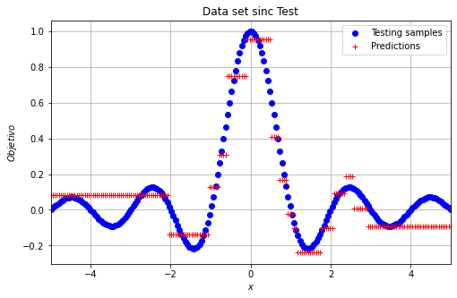

```python
#Test

yt = dtr.predict(xtest)

fig,ax = plt.subplots(figsize=(8,5))
ax.plot(xtest, ytest, 'bo', label='Testing samples')
ax.plot(xtest, yt, 'r+', label='Predictions')

ax.set_xlabel('$x$')
ax.set_ylabel('$Objetivo$')
ax.set_title('Data set sinc Test')

ax.set_xlim(left=np.min(xtest),right=np.max(xtest))
ax.grid(1)
ax.legend();
```

Podemos representar el árbol igual que en los problemas de clasificación con `plot_tree`.

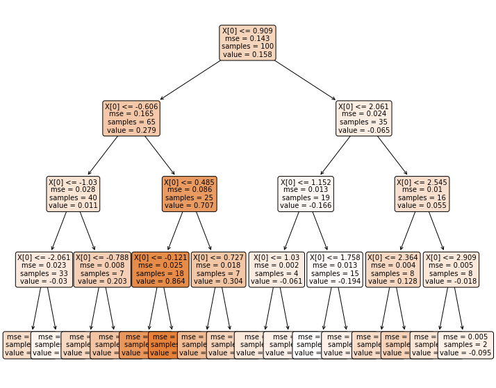

```python
from sklearn.tree import plot_tree
plt.figure(figsize=(12,10))
plot_tree(dtr, filled=True, rounded=True, fontsize=10);
```

**Ejercicio**. Utiliza `DecisionTreeRegression` con el dataset `load_diabetes`.

- Entrena un modelo con un 70% de las muestras.
- ¿Cuál es rendimiento (evalúalo mediante el coeficiente de determinación $R^2$) del modelo en test?
- Muestra el árbol gráficamente (Ten paciencia, cuesta un poco la generación !).
- ¿ Cómo podrías mejorar el rendimiento en test del árbol que has obtenido ? Consejo: analiza la profundidad del árbol (max_depth) y el numero de muestras por hoja (min_samples_leaf).
- Cuál es la diferencia entre optimizar el numero muestras por hoja y la profundidad del árbol? Qué metodo obtiene lo mejores resultados?
- Averigua las variables más importantes para el árbol en el problema de regresión propuesto con ambas optimizaciones.

```python
from sklearn.datasets import load_diabetes

diabetes = load_diabetes()
X, y = load_diabetes(return_X_y=True)
```

```python
xtrain, xtest, ytrain, ytest = train_test_split(X, y, test_size=0.3)
dtr = DecisionTreeRegressor()
dtr.fit(xtrain, ytrain)
```

```
DecisionTreeRegressor()
```

```python
from sklearn.metrics import r2_score, mean_squared_error

y_pred = dtr.predict(xtest)
r2 = r2_score(ytest, y_pred)
mse = mean_squared_error(ytest, y_pred)
print("R2 =", r2)
print("Mean Squared Error: ", mse)
```

```
R2 = -0.1204564839355482
Mean Squared Error:  6245.887218045113
```

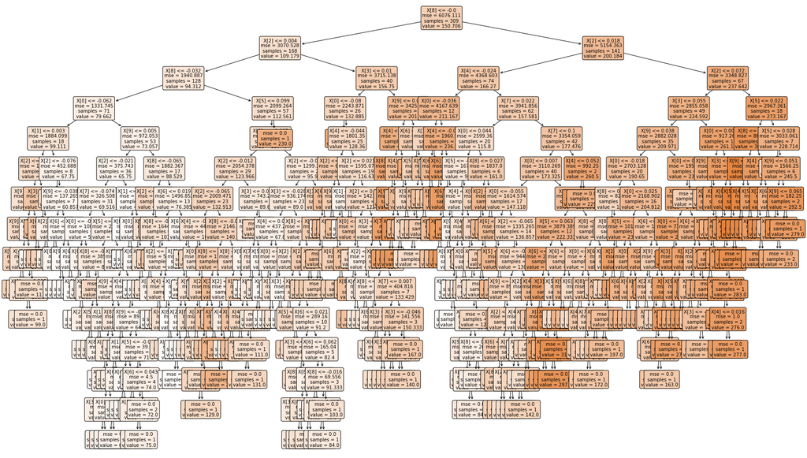

```python
plt.figure(figsize=(30,18))
plot_tree(dtr, filled=True, rounded=True, fontsize=10);
```

```python
# Barrido de la profundidad del árbol y el número mínimo de muestras por hoja
for depth in range(1, 11):
    for min_samples_leaf in range(1, 6):
        # Crear el modelo con la profundidad y número mínimo de muestras por hoja actuales
        dtr = DecisionTreeRegressor(max_depth = depth, min_samples_leaf = min_samples_leaf)

        # Entrenar el modelo
        dtr.fit(xtrain, ytrain)

        # Calcular los puntajes de entrenamiento y prueba
        train_score = dtr.score(xtrain, ytrain)
        test_score = dtr.score(xtest, ytest)

        # Imprimir los resultados
        print('Depth: {}, Min Samples Leaf: {}, Train Score: {:.4f}, Test Score: {:.4f}'.format(depth, min_samples_leaf, train_score, test_score))
```

```
Depth: 1, Min Samples Leaf: 1, Train Score: 0.3382, Test Score: 0.1507
Depth: 1, Min Samples Leaf: 2, Train Score: 0.3382, Test Score: 0.1507
Depth: 1, Min Samples Leaf: 3, Train Score: 0.3382, Test Score: 0.1507
Depth: 1, Min Samples Leaf: 4, Train Score: 0.3382, Test Score: 0.1507
Depth: 1, Min Samples Leaf: 5, Train Score: 0.3382, Test Score: 0.1507
Depth: 2, Min Samples Leaf: 1, Train Score: 0.4968, Test Score: 0.2424
Depth: 2, Min Samples Leaf: 2, Train Score: 0.4968, Test Score: 0.2424
Depth: 2, Min Samples Leaf: 3, Train Score: 0.4968, Test Score: 0.2424
Depth: 2, Min Samples Leaf: 4, Train Score: 0.4968, Test Score: 0.2424
Depth: 2, Min Samples Leaf: 5, Train Score: 0.4968, Test Score: 0.2424
Depth: 3, Min Samples Leaf: 1, Train Score: 0.5695, Test Score: 0.2086
Depth: 3, Min Samples Leaf: 2, Train Score: 0.5695, Test Score: 0.2086
Depth: 3, Min Samples Leaf: 3, Train Score: 0.5695, Test Score: 0.2086
Depth: 3, Min Samples Leaf: 4, Train Score: 0.5695, Test Score: 0.2086
Depth: 3, Min Samples Leaf: 5, Train Score: 0.5695, Test Score: 0.2086
Depth: 4, Min Samples Leaf: 1, Train Score: 0.6659, Test Score: 0.2530
Depth: 4, Min Samples Leaf: 2, Train Score: 0.6649, Test Score: 0.1949
Depth: 4, Min Samples Leaf: 3, Train Score: 0.6649, Test Score: 0.1949
Depth: 4, Min Samples Leaf: 4, Train Score: 0.6649, Test Score: 0.1429
Depth: 4, Min Samples Leaf: 5, Train Score: 0.6626, Test Score: 0.1515
Depth: 5, Min Samples Leaf: 1, Train Score: 0.7475, Test Score: 0.1218
Depth: 5, Min Samples Leaf: 2, Train Score: 0.7509, Test Score: 0.0752
Depth: 5, Min Samples Leaf: 3, Train Score: 0.7464, Test Score: 0.0905
Depth: 5, Min Samples Leaf: 4, Train Score: 0.7338, Test Score: 0.0326
Depth: 5, Min Samples Leaf: 5, Train Score: 0.7215, Test Score: 0.0944
Depth: 6, Min Samples Leaf: 1, Train Score: 0.8193, Test Score: 0.1075
Depth: 6, Min Samples Leaf: 2, Train Score: 0.8328, Test Score: 0.0411
Depth: 6, Min Samples Leaf: 3, Train Score: 0.8230, Test Score: 0.0118
Depth: 6, Min Samples Leaf: 4, Train Score: 0.8055, Test Score: -0.0911
Depth: 6, Min Samples Leaf: 5, Train Score: 0.7880, Test Score: -0.0144
Depth: 7, Min Samples Leaf: 1, Train Score: 0.8822, Test Score: 0.0022
Depth: 7, Min Samples Leaf: 2, Train Score: 0.8891, Test Score: -0.1571
Depth: 7, Min Samples Leaf: 3, Train Score: 0.8779, Test Score: 0.0323
Depth: 7, Min Samples Leaf: 4, Train Score: 0.8517, Test Score: -0.0914
Depth: 7, Min Samples Leaf: 5, Train Score: 0.8216, Test Score: -0.0691
Depth: 8, Min Samples Leaf: 1, Train Score: 0.9387, Test Score: -0.0710
Depth: 8, Min Samples Leaf: 2, Train Score: 0.9327, Test Score: 0.0014
Depth: 8, Min Samples Leaf: 3, Train Score: 0.9051, Test Score: -0.0145
Depth: 8, Min Samples Leaf: 4, Train Score: 0.8605, Test Score: -0.0840
Depth: 8, Min Samples Leaf: 5, Train Score: 0.8223, Test Score: -0.0706
Depth: 9, Min Samples Leaf: 1, Train Score: 0.9745, Test Score: -0.1445
Depth: 9, Min Samples Leaf: 2, Train Score: 0.9540, Test Score: -0.1395
Depth: 9, Min Samples Leaf: 3, Train Score: 0.9071, Test Score: -0.0154
Depth: 9, Min Samples Leaf: 4, Train Score: 0.8610, Test Score: -0.0977
Depth: 9, Min Samples Leaf: 5, Train Score: 0.8228, Test Score: -0.0770
Depth: 10, Min Samples Leaf: 1, Train Score: 0.9932, Test Score: -0.0688
Depth: 10, Min Samples Leaf: 2, Train Score: 0.9596, Test Score: -0.1265
Depth: 10, Min Samples Leaf: 3, Train Score: 0.9080, Test Score: -0.0151
Depth: 10, Min Samples Leaf: 4, Train Score: 0.8618, Test Score: -0.0577
Depth: 10, Min Samples Leaf: 5, Train Score: 0.8236, Test Score: -0.0825
```

La profundidad 3 o 4 tienen un rendimiento relativamente mejor en el conjunto de prueba en comparación con profundidades más altas.

La profundidad del árbol significa cuántos pasos o niveles puede tener el árbol desde arriba (la raíz) hasta abajo (las hojas). Si aumentas la profundidad, el modelo puede aprender patrones más complicados en los datos de entrenamiento.

El número mínimo de muestras por hoja es la cantidad más pequeña de datos necesaria para que un punto en el árbol sea una hoja, es decir, un punto final que no se divide más. Si aumentas este número, estás aplicando un tipo de ajuste que evita divisiones que generan nodos con muy pocos datos. Esto puede ayudar a prevenir que el modelo se ajuste demasiado a los datos, haciéndolo más suave y generalizable.

```python
mejor_h = 6 # muestras por hoja

dtr = DecisionTreeRegressor(min_samples_leaf=mejor_h)
dtr.fit(xtrain, ytrain)

importancia = dtc.feature_importances_
nombres = diabetes.feature_names
nombres = np.array(nombres)
ind = np.argsort(importancia)[::-1]

imp_df = pd.DataFrame({'Variable': nombres[ind], 'Importancia': importancia[ind]})
print(imp_df)

mejor_p = 3 # profundidad

dtr = DecisionTreeRegressor(max_depth = mejor_p)
dtr.fit(xtrain, ytrain)

importancia = dtc.feature_importances_
nombres = diabetes.feature_names
nombres = np.array(nombres)
ind = np.argsort(importancia)[::-1]

imp_df = pd.DataFrame({'Variable': nombres[ind], 'Importancia': importancia[ind]})
print(imp_df)
```

```
  Variable  Importancia
0      age     0.710952
1      sex     0.175017
2      bmi     0.066165
3       bp     0.047866
  Variable  Importancia
0      age     0.710952
1      sex     0.175017
2      bmi     0.066165
3       bp     0.047866
```